# ICMPC17 Analysis

Kyle M. Lang & Eriko Fukuda

2023-05-18

# Setup & Data Preperation

First, we’ll prep the environment.

```r
rm(list = ls(all = TRUE))

library(magrittr)
library(dplyr)
library(lme4)
library(performance)
library(ggplot2)

source("helper_functions.R")

dataDir <- "../data/"
fn1     <- "PerMusA_N73.csv"
fn2     <- "Combined_sample size 73.csv"
```

Now, we’ll load and inspect the data.

```r
## Read the data:
dat0 <- read.csv2(paste0(dataDir, fn1))

## Temporarily exclude ID (for privacy purposes):
tmp <- dat0 %>% select(-multichar_response)

## Check data:
head(tmp)
```

|  | title | correct | response | response_time |
| --- | --- | --- | --- | --- |
| 1 | 2022_HJ | 1 | None | 400 |
| 2 | 2022_HJ | 0 | None | 400 |
| 3 | 2022_HJ | 1 | None | 401 |
| 4 | 2022_HJ | 1 | spac | 320 |
| 5 | 2022_HJ | 1 | None | 401 |
| 6 | 2022_HJ | 1 | spac | 271 |

```r
summary(tmp)
```

```
    title              correct         response         response_time
 Length:54604       Min.   :0.0000   Length:54604       Min.   :  0
 Class :character   1st Qu.:1.0000   Class :character   1st Qu.:396
 Mode  :character   Median :1.0000   Mode  :character   Median :399
                    Mean   :0.7785                      Mean   :382
                    3rd Qu.:1.0000                      3rd Qu.:400
                    Max.   :1.0000                      Max.   :430
```

```r
str(tmp)
```

```
'data.frame':   54604 obs. of  4 variables:
 $ title        : chr  "2022_HJ" "2022_HJ" "2022_HJ" "2022_HJ" ...
 $ correct      : int  1 0 1 1 1 1 1 1 1 0 ...
 $ response     : chr  "None" "None" "None" "spac" ...
 $ response_time: int  400 400 401 320 401 271 373 357 402 399 ...
```

```r
## Any missing data?
colMeans(is.na(dat0))
```

```
multichar_response              title            correct           response
                 0                  0                  0                  0
     response_time
                 0
```

```r
## Frequencies of categorical variables:
table(dat0$correct)
```

```
    0     1
12093 42511
```

```r
table(dat0$response)
```

```
 None  spac
42329 12275
```

```r
table(dat0$title)
```

```
2022_HJ 2022_HP 2022_NE 2022_NS
  13651   13651   13651   13651
```

We don’t need the bird sound condition, so we’ll drop those cases.

```r
## Drop the bird sound condition:
dat1 <- dat0 %>%
    filter(title != "2022_NE") %>%
    rename(id = multichar_response) %>%
    mutate(cond = factor(title,
                         levels = c("2022_NS", "2022_HJ", "2022_HP"),
                         labels = c("none", "jazz", "pop")
                         )
           )

## Check the results:
dat1 %>% select(-id) %>% head()
```

|  | title | correct | response | response_time | cond |
| --- | --- | --- | --- | --- | --- |
| 1 | 2022_HJ | 1 | None | 400 | jazz |
| 2 | 2022_HJ | 0 | None | 400 | jazz |
| 3 | 2022_HJ | 1 | None | 401 | jazz |
| 4 | 2022_HJ | 1 | spac | 320 | jazz |
| 5 | 2022_HJ | 1 | None | 401 | jazz |
| 6 | 2022_HJ | 1 | spac | 271 | jazz |

```r
summary(dat1)
```

```
      id               title              correct        response
 Length:40953       Length:40953       Min.   :0.000   Length:40953
 Class :character   Class :character   1st Qu.:1.000   Class :character
 Mode  :character   Mode  :character   Median :1.000   Mode  :character
                                       Mean   :0.778
                                       3rd Qu.:1.000
                                       Max.   :1.000
 response_time     cond
 Min.   :  0.0   none:13651
 1st Qu.:396.0   jazz:13651
 Median :399.0   pop :13651
 Mean   :381.9
 3rd Qu.:400.0
 Max.   :430.0
```

```r
levels(dat1$cond)
```

```
[1] "none" "jazz" "pop"
```

```r
dat1 %$% table(cond, title)
```

```
      title
cond   2022_HJ 2022_HP 2022_NS
  none       0       0   13651
  jazz   13651       0       0
  pop        0   13651       0
```

Now, we’re ready to fit the models.

# Modeling

Before estimating the hypothesized models, we need to check the influence of the nesting. So, we’ll calculate the ICC to see how much variability is explained by the individuals’ self-similarities.

```r
## Estimate a random intercept-only model to calculate ICC:
fit0 <- glmer(correct ~ (1|id), data = dat1, family = "binomial")
summary(fit0)
```

```
Generalized linear mixed model fit by maximum likelihood (Laplace  Approximation)
 [glmerMod]
 Family: binomial  ( logit )
Formula: correct ~ (1 | id)
   Data: dat1

     AIC      BIC   logLik deviance df.resid
 41781.0  41798.2 -20888.5  41777.0    40951

Scaled residuals:
    Min      1Q  Median      3Q     Max
-5.0478  0.2268  0.4862  0.5829  0.8805

Random effects:
 Groups Name        Variance Std.Dev.
 id     (Intercept) 0.3645   0.6037
Number of obs: 40953, groups:  id, 73

Fixed effects:
            Estimate Std. Error z value Pr(>|z|)
(Intercept)  1.34799    0.07186   18.76   <2e-16 ***
---
Signif. codes:  0 '***' 0.001 '**' 0.01 '*' 0.05 '.' 0.1 ' ' 1
```

```r
icc(fit0)
```

| ICC_adjusted | ICC_unadjusted | optional |
| --- | --- | --- |
| 0.0997367 | 0.0997367 | FALSE |

The clustering doesn’t account for very much variability (i.e., 9.97%), but we will still control for it via a random intercept.

```r
## Fit the hypothesized model:
fit1 <- glmer(correct ~ cond + (1|id), data = dat1, family = "binomial")
summary(fit1)
```

```
Generalized linear mixed model fit by maximum likelihood (Laplace  Approximation)
 [glmerMod]
 Family: binomial  ( logit )
Formula: correct ~ cond + (1 | id)
   Data: dat1

     AIC      BIC   logLik deviance df.resid
 41768.0  41802.5 -20880.0  41760.0    40949

Scaled residuals:
    Min      1Q  Median      3Q     Max
-5.2313  0.2188  0.4838  0.5742  0.9006

Random effects:
 Groups Name        Variance Std.Dev.
 id     (Intercept) 0.3647   0.6039
Number of obs: 40953, groups:  id, 73

Fixed effects:
            Estimate Std. Error z value Pr(>|z|)
(Intercept)  1.32386    0.07382  17.933   <2e-16 ***
condjazz    -0.02045    0.02947  -0.694   0.4878
condpop      0.09498    0.02991   3.175   0.0015 **
---
Signif. codes:  0 '***' 0.001 '**' 0.01 '*' 0.05 '.' 0.1 ' ' 1

Correlation of Fixed Effects:
         (Intr) cndjzz
condjazz -0.200
condpop  -0.197  0.495
```

```r
fixef(fit1) %>% exp()
```

```
(Intercept)    condjazz     condpop
  3.7578823   0.9797579   1.0996351
```

Pop music produces significantly better results than no music ( $\beta = 0.095$, $OR = 1.1$, $z = 3.18$, $p = 0.001$ ), but results under jazz music and no music do not significantly differ ( $\beta = -0.02$, $OR = 0.98$, $z = -0.69$, $p = 0.488$ ).

```r
## Change the reference group to evaluate the other comparison:
fit2 <- dat1 %>%
    mutate(cond = relevel(cond, ref = "jazz")) %$%
    glmer(correct ~ cond + (1|id), family = "binomial")
summary(fit2)
```

```
Generalized linear mixed model fit by maximum likelihood (Laplace  Approximation)
 [glmerMod]
 Family: binomial  ( logit )
Formula: correct ~ cond + (1 | id)

     AIC      BIC   logLik deviance df.resid
 41768.0  41802.5 -20880.0  41760.0    40949

Scaled residuals:
    Min      1Q  Median      3Q     Max
-5.2313  0.2188  0.4838  0.5742  0.9006

Random effects:
 Groups Name        Variance Std.Dev.
 id     (Intercept) 0.3647   0.6039
Number of obs: 40953, groups:  id, 73

Fixed effects:
            Estimate Std. Error z value Pr(>|z|)
(Intercept)  1.30340    0.07386  17.648  < 2e-16 ***
condnone     0.02045    0.02947   0.694 0.487709
condpop      0.11543    0.02984   3.869 0.000109 ***
---
Signif. codes:  0 '***' 0.001 '**' 0.01 '*' 0.05 '.' 0.1 ' ' 1

Correlation of Fixed Effects:
         (Intr) condnn
condnone -0.198
condpop  -0.196  0.491
```

```r
fixef(fit2) %>% exp()
```

```
(Intercept)    condnone     condpop
   3.681791    1.020661    1.122355
```

# Diagnostics

Before we can interpret these findings, we need to check out model’s assumptions.

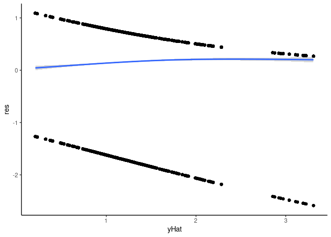

```r
## Estimate (deviance) residuals and fitted values (on the latent scale):
res  <- resid(fit2, type = "deviance")
yHat <- predict(fit2, type = "link")

## Plot residuals against fitted values:
data.frame(yHat, res) %>%
  ggplot(aes(yHat, res)) +
  geom_point() +
  geom_smooth() +
  theme_classic()
```

The deviance residuals don’t indicate any unmodeled nonlinearity.

```r
## Check homogeneity of residual variances:
resid(fit0, type = "deviance") %>% tapply(dat1$cond, var)
```

```
     none      jazz       pop
1.0013186 1.0118826 0.9477783
```

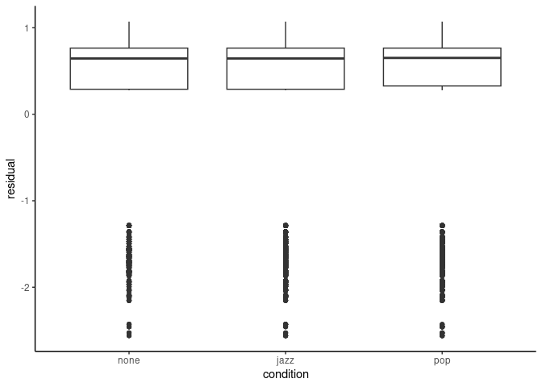

```r
## Check homogeneity and linearity:
data.frame(residual  = resid(fit0, type = "deviance"),
           condition = dat1$cond) %>%
  ggplot(aes(condition, residual)) +
  geom_boxplot() +
  theme_classic()
```

The residual variances appear to be approximately equal in each condition.

# Conclusions

Overall, we can make the following conclusions.

1. The assumptions seem to be satisfied.
2. The clustering effect is not very strong.
3. Pop music is significantly better than no sound.
4. Pop music is significantly better than jazz music.
5. There is no significant difference between no sound and jazz.